# DS 807 Take Home Exam

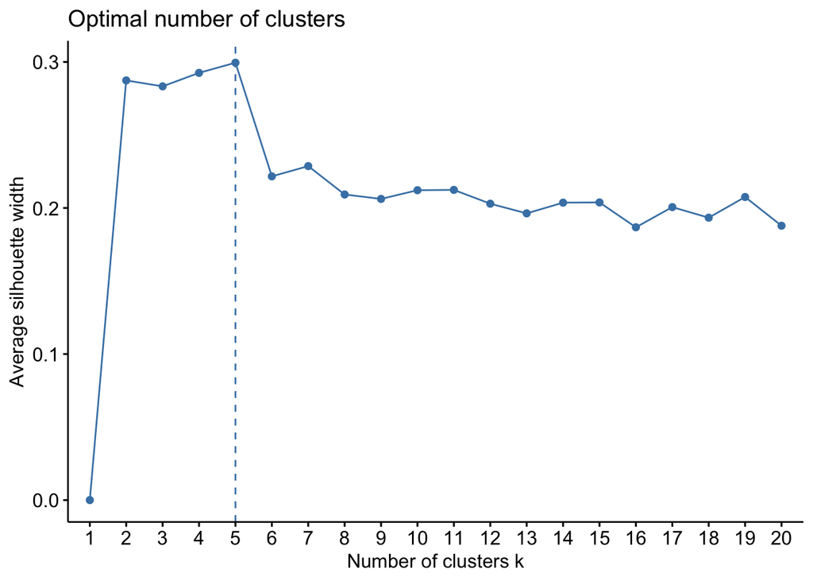

```r
fviz_nbclust(data2, kmeans, method = "silhouette",k.max=20)
```

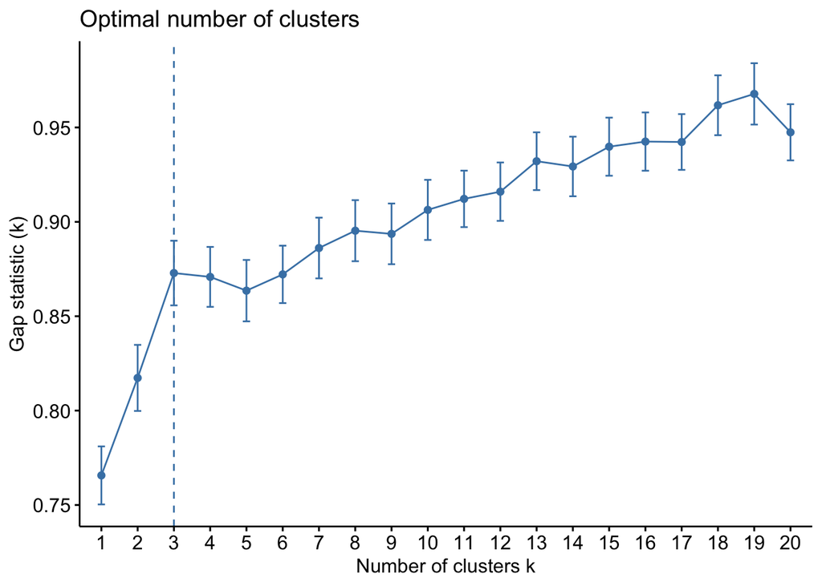

```r
fviz_nbclust(data2, kmeans, method = "gap_stat",k.max=20)
```

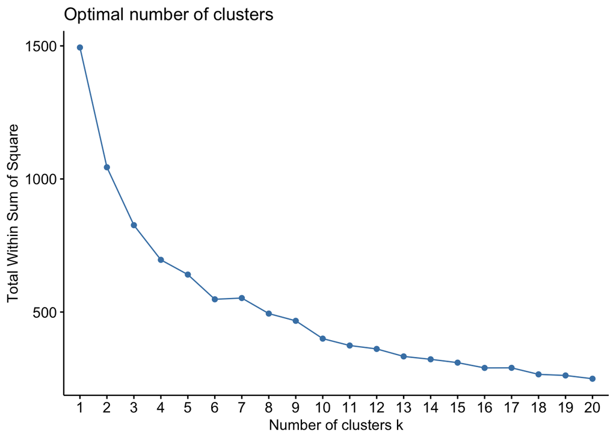

```r
fviz_nbclust(data2, kmeans, method = "wss", k.max=20)
```

3. (10 points) Use a hierarchical clustering or DBSCAN clustering algorithm.
   - Which algorithm did you use and why?

**I used hierarchical clustering with method complete beacuse it merges clusters sequentially**

```
- How did you decide on the parameters, i.e. h, k, $\varepsilon$, or minPts?
```

```
- Are there any benefits or disadvantages of using the algorithm you chose over the other?
```

**I used hierarchical clustering with method complete because hierarchical representation can be very informative and easy to implement.**

```r
hclust.comp = hclust(dist(data2), method="complete")
hclust.comp
```

```
##
## Call:
## hclust(d = dist(data2), method = "complete")
##
## Cluster method   : complete
## Distance         : euclidean
## Number of objects: 167
```

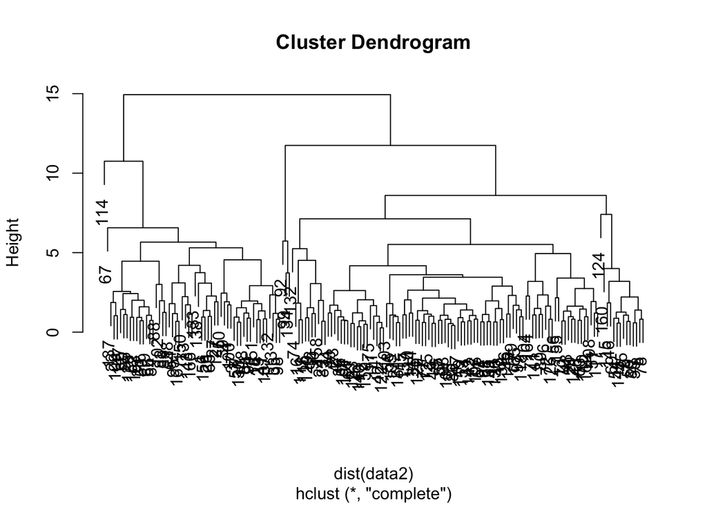

```r
plot(hclust.comp)
```

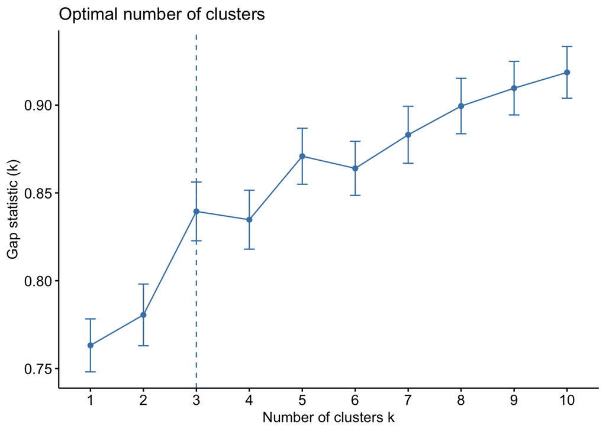

```r
#calculate gap statistic for each number of clusters (up to 10 clusters)
gap_stat <- clusGap(data2, FUN = hcut, nstart = 25, K.max = 10, B = 50)

#produce plot of clusters vs. gap statistic
fviz_gap_stat(gap_stat)
```

```r
cut.out = cutree(hclust.comp, h=10)
cut.out
```

```
##   [1] 1 2 2 1 2 2 2 2 2 2 2 2 2 2 2 2 2 1 1 2 2 1 2 2 2 1 1 1 1 2 2 1 1 2 2 2 1
##  [38] 1 1 2 1 2 2 2 2 2 2 2 2 1 2 2 1 2 2 2 1 2 2 1 2 2 2 1 1 1 1 2 2 2 2 2 1 2
##  [75] 2 2 2 2 2 2 1 1 2 1 1 2 2 1 1 2 2 3 2 1 1 2 2 1 3 1 2 1 2 2 2 2 1 2 1 2 2
## [112] 2 1 4 2 2 2 2 2 2 2 2 2 2 2 2 1 1 2 1 2 2 1 3 2 2 1 1 2 2 2 2 1 2 2 2 1 1
## [149] 2 1 1 1 2 2 2 1 2 2 2 2 2 2 1 2 2 1 1
```

```r
cut.out = cutree(hclust.comp, k=3)
cut.out
```

```
##   [1] 1 2 2 1 2 2 2 2 2 2 2 2 2 2 2 2 2 1 1 2 2 1 2 2 2 1 1 1 1 2 2 1 1 2 2 2 1
##  [38] 1 1 2 1 2 2 2 2 2 2 2 2 1 2 2 1 2 2 2 1 2 2 1 2 2 2 1 1 1 1 2 2 2 2 2 1 2
##  [75] 2 2 2 2 2 2 1 1 2 1 1 2 2 1 1 2 2 3 2 1 1 2 2 1 3 1 2 1 2 2 2 2 1 2 1 2 2
## [112] 2 1 1 2 2 2 2 2 2 2 2 2 2 2 2 1 1 2 1 2 2 1 3 2 2 1 1 2 2 2 2 1 2 2 2 1 1
## [149] 2 1 1 1 2 2 2 1 2 2 2 2 2 2 1 2 2 1 1
```

4. (15 points) Explain your “best” (based on your point of view) clustering algorithm. While doing so, please focus on the following:
   - Reason why you think this algorithm is the best
   - What insights can we gain from your analysis?
   - Were you able to gain insight you foresaw in question 1 of part 2?

**Beased on my point of view best clustering algorithm is hierarchical clustering. hierarchical clustering is one of the simplest and popular unsupervised machine learning algorithms.We don’t have to pre-specify any particular number of clusters we can also obtain any desired number of clusters by cutting the Dendrogram at the proper level.This method is easy to decide the number of clusters by merely looking at the Dendrogram.**

**Through my analysis I was able to classify countries into 3 different categories based on the socio economic factors and on bases of health of people in the country**

**Yes! I had in mind that we can differniate country into differerent categories based on all the data I’m provided.I believe I’m succesful in it.**

### Part 3: Self-Reflection (10 points total)

Write a self reflection on your performance in this exam answering the following points:

- What parts of it did you particularly like? Dislike? For the parts you disliked, is there anything you can do to improve?

**I love working with real data which is fun.I felt so satisfied while doing text analysis also felt more confident in text analysis.**

- What is one thing you are proud of?

**I’m proud that I was able to do topic model and on the fact that I was thinking like an analyst to find out what the incomplete word was (dai) and was able to correctly analysis**

- As you look at this piece, what’s one thing that you would like to try to improve upon?

- Overall, are you satisfied with your performance? What grade you would give yourself?

**I felt really professional like I was working for someone to analysis data according to his need. I will grade me A for all work I have done.**